# Nearest Neighbors

## This notebook includes:

- Data-wrangling for spatial dynamics, using "SCTLD_END_exta.csv"
- Euclidean Distance distribution for all colonies and just diseased colonies (Figure 6)
- Kolmogorov-Smirnoc test for euclidian distances
- Nearest Previously Diseased neighbor monte carlo analysis, as well as supplemental nearest neighbor and nearest diseased neighbor analyses.

```
[1] "/Users/saradellwilliams/Dropbox/My_Publications/SpatEpiSCTLD/SCTLDepizootiology_lowerFLkeys/SpatialAnalyses"
```

```r
my.data<-read.csv("SCTLD_END_exta.csv")
##makes a column with factors for if the coral got disease or not throughout the entire survey
#summary(my.data)
my.data$glom<-as.factor(my.data$total_bin)
my.data$glom<-revalue(my.data$glom, c("0"="Healthy", "1"="SCTLD"))
```

```r
#now keeping data in the wide format
#need just suscpetible species
dis.sps<-my.data%>%
  filter(Sps!="AAGA",Sps!="ACER",Sps!="ATEN",Sps!="EFAS",Sps!="MANG",Sps!="MMEA",Sps!="MYCE",Sps!="OCUL",Sps!="ODIF",Sps!="PAST",Sps!="PDIV",Sps!="PPOR",Sps!="SRAD")%>%
  droplevels()
```

```r
#ok, shorten dis.sps dataset to just 10/30/19-12/6/19, becuase didnt see disease until then
## this is the wide format dataset
#colnames(dis.sps)
my.datas<-dis.sps%>%
  dplyr::select(Site,Plot,Sps,coords_x,coords_y,X8.17.18,X10.30.18,X11.9.18,X11.29.18,X12.13.18,X1.4.19,X1.18.19,X2.8.19,X3.4.19,X3.21.19,X4.11.19,X5.2.19,X5.16.19,X5.28.19,X6.13.19,X7.1.19,X7.22.19,X8.16.19,X9.17.19,X10.14.19,X11.12.19,X12.6.19,glom)
#colnames(my.datas)
#refactor data to all have same levels
my.datas$X8.17.18<-factor(my.datas$X8.17.18,levels=c("Healthy","SCTLD","Dead","Unknown"))
my.datas$X10.30.18<-factor(my.datas$X10.30.18,levels=c("Healthy","SCTLD","Dead","Unknown"))
my.datas$X11.9.18<-factor(my.datas$X11.9.18,levels=c("Healthy","SCTLD","Dead","Unknown"))
my.datas$X11.29.18<-factor(my.datas$X11.29.18,levels=c("Healthy","SCTLD","Dead","Unknown"))
my.datas$X12.13.18<-factor(my.datas$X12.13.18,levels=c("Healthy","SCTLD","Dead","Unknown"))
my.datas$X1.4.19<-factor(my.datas$X1.4.19,levels=c("Healthy","SCTLD","Dead","Unknown"))
my.datas$X1.18.19<-factor(my.datas$X1.18.19,levels=c("Healthy","SCTLD","Dead","Unknown"))
my.datas$X2.8.19<-factor(my.datas$X2.8.19,levels=c("Healthy","SCTLD","Dead","Unknown"))
my.datas$X3.4.19<-factor(my.datas$X3.4.19,levels=c("Healthy","SCTLD","Dead","Unknown"))
my.datas$X3.21.19<-factor(my.datas$X3.21.19,levels=c("Healthy","SCTLD","Dead","Unknown"))
my.datas$X4.11.19<-factor(my.datas$X4.11.19,levels=c("Healthy","SCTLD","Dead","Unknown"))
my.datas$X5.2.19<-factor(my.datas$X5.2.19,levels=c("Healthy","SCTLD","Dead","Unknown"))
my.datas$X5.16.19<-factor(my.datas$X5.16.19,levels=c("Healthy","SCTLD","Dead","Unknown"))
my.datas$X5.28.19<-factor(my.datas$X5.28.19,levels=c("Healthy","SCTLD","Dead","Unknown"))
my.datas$X6.13.19<-factor(my.datas$X6.13.19,levels=c("Healthy","SCTLD","Dead","Unknown"))
my.datas$X7.1.19<-factor(my.datas$X7.1.19,levels=c("Healthy","SCTLD","Dead","Unknown"))
my.datas$X7.22.19<-factor(my.datas$X7.22.19,levels=c("Healthy","SCTLD","Dead","Unknown"))
my.datas$X8.16.19<-factor(my.datas$X8.16.19,levels=c("Healthy","SCTLD","Dead","Unknown"))
my.datas$X9.17.19<-factor(my.datas$X9.17.19,levels=c("Healthy","SCTLD","Dead","Unknown"))
my.datas$X10.14.19<-factor(my.datas$X10.14.19,levels=c("Healthy","SCTLD","Dead","Unknown"))
my.datas$X11.12.19<-factor(my.datas$X11.12.19,levels=c("Healthy","SCTLD","Dead","Unknown"))
my.datas$X12.6.19<-factor(my.datas$X12.6.19,levels=c("Healthy","SCTLD","Dead","Unknown"))
#head(my.datas)
mcavs<-subset(my.datas,subset=Sps=="MCAV")
cnats<-subset(my.datas,subset=Sps=="CNAT")
ofav<-subset(my.datas,subset=Sps=="OFAV")
```

```r
my.datas<-dsto
#Split into plots for analysis
s3.p45<-my.datas%>%
  filter(Plot==45)
s3.p47<-my.datas%>%
  filter(Plot==47)
s1.p23<-my.datas%>%
  filter(Plot==23)
s1.p25<-my.datas%>%
  filter(Plot==25)
s2.p27<-my.datas%>%
  filter(Plot==27)
s2.p28<-my.datas%>%
  filter(Plot==28)
```

### Euclidean Distance analysis

#### Get euclidean distances (all colonies and just diseased) for each plot

```r
dis.dists<-disdists[disxy]
```

```
Error in disdists[disxy] : subscript out of bounds
```

Combine the distances from the plots

```r
all.disdists<-c(p23.disdists,p25.disdists,p27.disdists,p28.disdists,p45.disdists,p47.disdists)
```

```
Error: object 'p23.disdists' not found
```

#### Figure 6 Euclidean distances

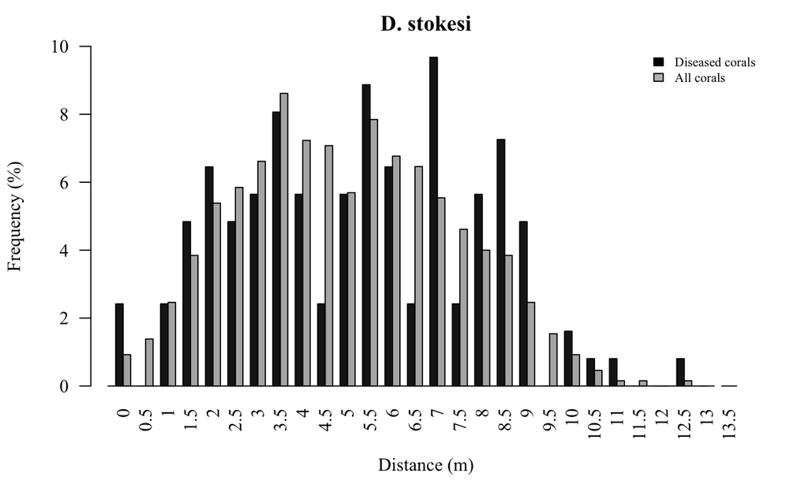

#### Kolmogorov smirnov test

```r
my.se<-function(x){
  sd(x,na.rm=TRUE)/sqrt(length(x))
}
ks.test(all.disdists,all.alldists,alternative="g")
```

```
p-value will be approximate in the presence of ties
```

```
    Two-sample Kolmogorov-Smirnov test

data:  all.disdists and all.alldists
D^+ = 0.029727, p-value = 0.8319
alternative hypothesis: the CDF of x lies above that of y
```

```r
#In the ks.test "greater" means that the CDF of 'x' is higher than the CDF of 'y' which means that things like the mean and the median will be smaller values in 'x' than in 'y' if the CDF of 'x' is "greater" than the CDF of 'y'.
mean(all.alldists)
```

```
[1] 5.18399
```

```r
my.se(all.alldists)
```

```
[1] 0.09267051
```

```r
mean(all.disdists)
```

```
[1] 5.491556
```

```r
my.se(all.disdists)
```

```
[1] 0.2399237
```

### Nearest Neightbors analysis

- nearest infected neighbor to diseased coral
- nearest neightbor to diseased coral
- nearest previously infected neighbor to new infected coral

1. Determine the distances to the nearest infected neighbor for all newly infected colonies and get the average nearest infected neighbor distance.
2. Shuffle the coordinates to randomize which colonies are the infected colonies at each time point
3. For the shuffled data, determine the distances to the nearest infected neighbor for all newly infected colonies and get the average nearest infected neighbor distance.
4. Repeat steps 2 & 3 100 times
5. Determine the number of times that the realized average nearest infected neighbor distance is greater than the shuffled average nearest infected neighbor distance.
6. The p value is the value calculated in step 5 divided by the number of simulations

#### Functions needed

```r
get_prevIdistmat<-function(df,plot){
  ####newly infected corals
  newly_I<-matrix(0, nrow = nrow(df), ncol = 22) #blank matrix for storing newly infected   corals
  for (i in 1:(22)){ #for each survey time point
    col<-5+i #start with first tp after init tp
  #print(col)
  #print(df[,col])
    prev<-5+i-1
  #print(prev)
    for (j in 1:(nrow(df))){ #for each row in the df
    #print (df[j,col])
      if ( df[j,col]=="SCTLD" ){ #if it's disease
      #print( "found one")
        if (df[j,prev]!="SCTLD"){ # and if it wasnt diseased before
          newly_I[j,i]<-1 #add it to newly infected
        }
      }
    }
  }
#dim(newly_I)
  if(plot==45){
    newly_I[43,15]<-0
    newly_I[40,19]<-0
    newly_I[40,15]<-0
    newly_I[37,15]<-0
  }
  if(plot==47){
    newly_I[2,21]<-0 #for plot 47
  }
  #if (sum(rowSums(newly_I))>nrow(df)){
    #print("ERROR")
    #print(rowSums(newly_I))
  #}
  ##diseased or not matrix
  range<-ncol(df)
  df_dis_short<-df[,6:range] #shorten the dataframe to just the month data
#nrow(df_dis_short)
  dis_or_not<-matrix(0,nrow=nrow(df_dis_short),ncol=ncol(df_dis_short)) #set up blank matrix to store the dis or not as 1s and 0s
  for (i in 1:nrow(dis_or_not)){ #over each row
    for (j in 1:ncol(dis_or_not)){ #over each column
      if (df_dis_short[i,j]=="SCTLD"){ #if not healthy
        dis_or_not[i,j]<-1 #label as diseased / 1 in new matrix
      }
    }
  }
#dim(dis_or_not)
###### get distances to previously infected corals mat where timepoints are columns and corals are rows
  distmat<-as.matrix(dist(cbind(df$coords_x,df$coords_y)))
  dist_to_nearest_prev_I<-c() #set up blank list to track nearest infected neighbor to newly infected
  track_dists_newlyI <- matrix(NA,nrow(df)) #blank matrix for storing all distances between old inf and new inf
#dim(newly_I)
  for (i in 1:nrow(newly_I)){ #for each row in newly_I, which is each coral
  #print(i)
    for (j in 1:ncol(newly_I)){ #for each column in newly_I, which is each time point
    #print(j)
      coral<-newly_I[i,j] #choose a coral at the timepoint
      if (coral>0){ #if the coral is newly infected (1)
      #print("new inf coral")
      #print(i)
      #print(j)
        mat_prev_inf<-as.matrix(dis_or_not[,j]) #choose the column before coral's column to get 1 inf and 0 not infected; because dis_or_not has all time point columns j is the timepoint before the timepoint being pulled from the newly_I
      #mat_prev_inf is a matrix of 1 column (the timepoint before the coral timepoint we are considering) where 0 is not infected and 1 is infected
      #print(mat_prev_inf)
        dists_between_newI_coral_and_all<-distmat[,i] #choose the ith column of the distance matrix which will be the column of the coral we are looking at as newly infected --> this will be a numeric class
        all_dists_between_newI_coral_and_prevI_coral<-dists_between_newI_coral_and_all*mat_prev_inf #row will be 0 if the prev time point it was not infected. it will be the distance if it was previously infected
        track_dists_newlyI<-cbind(track_dists_newlyI,all_dists_between_newI_coral_and_prevI_coral) #track all of these distances
      #dists_between_newI_coral_and_prevI_coral<-all_dists_between_newI_coral_and_prevI_coral[which(rowSums(all_dists_between_newI_coral_and_prevI_coral) > 0),]  #get rid of zeros
      #print(dists_between_newI_coral_and_prevI_coral)
      #dist_to_nearest_prev_I<-append(dist_to_nearest_prev_I,min(dists_between_newI_coral_and_prevI_coral)) #append the minimum dist to prev inf to the list
      }
    }
  }
return(track_dists_newlyI)
}
#get_NPDNmat(df,plot)
nn_prevI_to_newI<-function(dists){
  #dists is a matrix where each column is a coral and it's distances to previously infected corals (each row is a dif coral and the val is dist, 0 if not infected before the colyumn coral)
  nn_newIprevI<-c()
  for (i in 2:ncol(dists)){
    coralcol<-dists[,i] #choose one colony to look at
    #print(coralcol)
    coralcol<-as.matrix(coralcol) #turn it into a matrix
    coralcol<-coralcol[which(rowSums(coralcol)>0)] #get rid of zeros
    nn_newIprevI<-append(nn_newIprevI,min(coralcol)) #get the nearest neighbor distance
  }
  return(nn_newIprevI)
}
```

### nearest neighbors for all corals

```r
s3.p47n
```

```
   Site Plot  Sps   coords_x   coords_y X8.17.18 X10.30.18 X11.9.18 X11.29.18
1     3   47 MCAV  0.7419330 0.23811251  Healthy   Healthy  Healthy   Healthy
2     3   47 MCAV  0.2228970 1.40189565  Healthy   Healthy  Healthy   Healthy
3     3   47 MCAV  0.2435770 3.33534387  Healthy   Healthy  Healthy   Healthy
4     3   47 MCAV -0.0196821 4.83388132  Healthy   Healthy  Healthy   Healthy
5     3   47 MCAV  0.8341760 5.63862497  Healthy   Healthy  Healthy   Healthy
6     3   47 MCAV  0.7707760 7.17160609  Healthy   Healthy  Healthy   Healthy
7     3   47 MCAV  0.2567740 7.10208385  Healthy   Healthy  Healthy   Healthy
8     3   47 MCAV  0.5156800 6.67018888  Healthy   Healthy  Healthy   Healthy
9     3   47 MCAV  0.2827600 7.73556155  Healthy   Healthy  Healthy   Healthy
10    3   47 MCAV -0.0629464 8.43364096  Healthy   Healthy  Healthy   Healthy
11    3   47 MCAV  0.1641230 8.80156913  Healthy   Healthy  Healthy   Healthy
12    3   47 MCAV  0.7336340 9.27139974  Healthy   Healthy  Healthy   Healthy
13    3   47 MCAV  0.5310540 9.90360763  Healthy   Healthy  Healthy   Healthy
14    3   47 MCAV  1.2283168 0.07414798  Healthy   Healthy  Healthy   Healthy
```

[output cut: 130 more lines]

nearest diseased neighbors for diseased corals

```r
s3.p45d<-na.omit(subset(s3.p45n,subset=glom=="SCTLD"))
s3.p45d$NDN<-nndist(s3.p45d$coords_x,s3.p45d$coords_y)
s3.p47d<-na.omit(subset(s3.p47n,subset=glom=="SCTLD"))
s3.p47d$NDN<-nndist(s3.p47d$coords_x,s3.p47d$coords_y)
s1.p23d<-na.omit(subset(s1.p23n,subset=glom=="SCTLD"))
s1.p23d$NDN<-nndist(s1.p23d$coords_x,s1.p23d$coords_y)
s1.p25d<-na.omit(subset(s1.p25n,subset=glom=="SCTLD"))
s1.p25d$NDN<-nndist(s1.p25d$coords_x,s1.p25d$coords_y)
s2.p27d<-na.omit(subset(s2.p27n,subset=glom=="SCTLD"))
s2.p27d$NDN<-nndist(s2.p27d$coords_x,s2.p27d$coords_y)
s2.p28d<-na.omit(subset(s2.p28n,subset=glom=="SCTLD"))
s2.p28d$NDN<-nndist(s2.p28d$coords_x,s2.p28d$coords_y)
```

#### Do multiple simulations for monte carlo randomization stat method.

```r
for (i in 1:6){
  #nearest previously infected coral to newly infected coral
  plot<-plotnumbers[i]
  plotdis<-as.data.frame(plotdisdata[i])
  df<-plotdis#[,-c(28,29,30,31)]
  dists_prevInewI<-get_prevIdistmat(df,plot)
  nnprevI<-nn_prevI_to_newI(dists_prevInewI)
  nnprevI<-nnprevI[!is.infinite(nnprevI)] #remove infs
  all.nnprevI<-c(all.nnprevI,nnprevI)

  #nearest neighbors and euclidean distances for all colonies
  plotnum<-as.data.frame(sites[i])
  coords<-na.omit(cbind(plotnum$coords_x,plotnum$coords_y))
  all.nn<-c(all.nn,nndist(coords)) #nearest neighbors
  alldists<-as.matrix(dist(coords))
  allxy<-t(combn(colnames(alldists), 2))
  all.dists<-alldists[allxy]
  all.all.dists<-c(all.all.dists,all.dists) #euclidean distances

  #nearest diseased neighbors for diseased colonies and euclidean distances btwn dis corals
  discoords<-na.omit(subset(plotnum,subset=glom=="SCTLD",select=c(coords_x,coords_y)))
  disdists<-as.matrix(dist(discoords))
  all.ndn<-c(all.ndn,nndist(discoords)) #nearest diseased neighbors
  all.2ndn<-c(all.2ndn,nndist(discoords,k=2)) #second nearest
  all.3ndn<-c(all.3ndn,nndist(discoords,k=3)) #third nearest
  disxy<-t(combn(colnames(disdists), 2))
  dis.dists<-disdists[disxy]
  all.dis.dists<-c(all.dis.dists,dis.dists) #euclidean distances
}
```

[output not shown]

```r
#all euclidean dist
print("all colonies euclidean distances mean and SE")
```

```
[1] "all colonies euclidean distances mean and SE"
```

```r
mean(all.all.dists)
```

```
[1] 5.132004
```

```r
my.se(all.all.dists)
```

```
[1] 0.005452808
```

```r
#dis dists
print("Just Disease colonies euclidean distances mean and SE")
```

```
[1] "Just Disease colonies euclidean distances mean and SE"
```

```r
mean(all.dis.dists)
```

```
[1] 4.831637
```

```r
my.se(all.dis.dists)
```

```
[1] 0.03717588
```

```r
#real.anpin<-mean(all.nnprevI)
#real.ann<-mean(all.nn)
#real.andn<-mean(all.ndn)
#real.a2ndn<-mean(all.2ndn)
#real.a3ndn<-mean(all.3ndn)
#all nn
print("all colonies nearest neighbors distances mean and SE")
```

```
[1] "all colonies nearest neighbors distances mean and SE"
```

```r
mean(all.nn)
```

```
[1] 0.3228695
```

```r
my.se(all.nn)
```

```
[1] 0.004405357
```

```r
# ndn
print("nearest diseased neighbors distances mean and SE")
```

```
[1] "nearest diseased neighbors distances mean and SE"
```

```r
mean(all.ndn)
```

```
[1] 0.8539544
```

```r
my.se(all.ndn)
```

```
[1] 0.05469958
```

```r
# rand ndn
print("random nearest diseased neighbors distances mean and SE")
```

```
[1] "random nearest diseased neighbors distances mean and SE"
```

```r
mean(rand.ndn)
```

```
[1] 0.8418264
```

```r
my.se(rand.ndn)
```

```
[1] 0.0470854
```

```r
# npin
print("nearest previously diseased neighbor distances mean and SE")
```

```
[1] "nearest previously diseased neighbor distances mean and SE"
```

```r
mean(all.nnprevI)
```

```
[1] 1.836995
```

```r
my.se(all.nnprevI)
```

```
[1] 0.1385411
```

```r
# rand npdn
print("randomized nearest previously diseased neighbor distances mean and SE")
```

```
[1] "randomized nearest previously diseased neighbor distances mean and SE"
```

```r
mean(rand.nnprevI)
```

```
[1] 1.788464
```

```r
my.se(rand.nnprevI)
```

```
[1] 0.126464
```